# Managing frame gaps with pathviewr

Melissa S. Armstrong

2025-06-13

## Defining trajectories with `pathviewr`

`pathviewr` defines trajectories as continuous movement from one side of a region of interest to the other. Before trajectories can be defined, the region of interest must be selected via `select_x_percent()` in addition to all the previous steps of the data import and cleaning pipeline as described in [the Data Import and Cleaning vignette](https://docs.ropensci.org/pathviewr/articles/data-import-cleaning.html). We’ll start with loading `pathviewr` and a few packages from the `tidyverse` and importing our data.

```r
## If you do not already have pathviewr installed:
# install.packages("devtools")
# devtools::install_github("ropensci/pathviewr")

library(pathviewr)
library(ggplot2)
library(magrittr)

## Import the example Motive data included in
## the package
motive_data <-
  read_motive_csv(
    system.file("extdata", "pathviewr_motive_example_data.csv",
                package = 'pathviewr')
  )
```

We’ll quickly run through the cleanup pipeline using one of `pathviewr`’s all-in-one cleaning functions as described in [the Data Import and Cleaning vignette](https://docs.ropensci.org/pathviewr/articles/data-import-cleaning.html). Since trajectories are defined in the `separate_trajectories()` function, we’ll stop the all-in-one there by setting it and every step after it to `FALSE` so we can take a closer look at how trajectories are defined. Since all steps are set to `TRUE` by default, we don’t actually need to list them in the function, just those we want to switch to `FALSE` or those that require additional arguments.

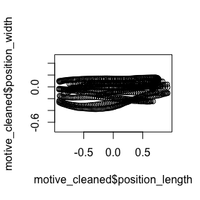

```r
motive_cleaned <-
  motive_data %>%
  clean_viewr(
    desired_percent = 70,
    rename_viewr_characters = FALSE,
    separate_trajectories = FALSE,
    get_full_trajectories = FALSE
  )

## Quick plot
plot(motive_cleaned$position_length,
     motive_cleaned$position_width,
     asp = 1)
```

### Inspecting the data

We’ve cleaned up our data and are ready to link individual data points into continuous trajectories. Deciding exactly how to define a trajectory will depend largely on the quality of data collected and the resolution required to answer a given question about the data. If the data are fairly continuous and high resolution is required, the default `max_frame_gap = 1` will not allow any frame gaps–movement must be continuous.

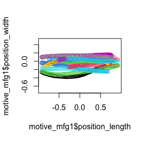

```r
motive_mfg1 <-
  motive_cleaned %>%
  separate_trajectories(
    max_frame_gap = 1
  )

## Quick plot
plot(motive_mfg1$position_length,
     motive_mfg1$position_width,
     asp = 1, col = as.factor(motive_mfg1$file_sub_traj))
```

```r
## How many trajectories do we end up with?
length(unique(motive_mfg1$file_sub_traj))
```

```
#> [1] 16
```

Plotting each trajectory reveals that perhaps some trajectories that should be continuous have been split into two or more separate trajectories because of a dropped frame or two. This data may require relaxing the stringent no-frame-gaps requirement in order to link data points that should go together into a single trajectory. Let’s try setting `max_frame_gap = 5`.

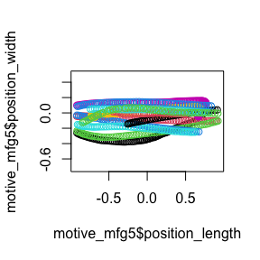

```r
motive_mfg5 <-
  motive_cleaned %>%
  separate_trajectories(
    max_frame_gap = 5
  )

## Quick plot
plot(motive_mfg5$position_length,
     motive_mfg5$position_width,
     asp = 1, col = as.factor(motive_mfg5$file_sub_traj))
```

```r
## How many trajectories do we end up with?
length(unique(motive_mfg5$file_sub_traj))
```

```
#> [1] 13
```

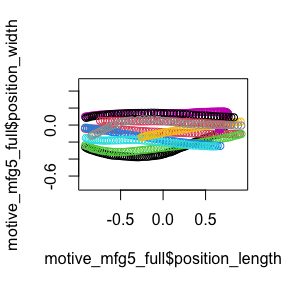

```r
motive_mfg5_full <-
  motive_mfg5 %>%
  get_full_trajectories(
    span = .6
  )

## Quick plot
plot(motive_mfg5_full$position_length,
     motive_mfg5_full$position_width,
     asp = 1, col = as.factor(motive_mfg5_full$file_sub_traj))
```

```r
## How many trajectories do we end up with?
length(unique(motive_mfg5_full$file_sub_traj))
```

```
#> [1] 10
```

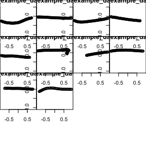

```r
## Plot each trajectory
plot_viewr_trajectories(motive_mfg5_full,
                        plot_axes = c("length", "width"),
                        multi_plot = TRUE)
```

### Visualize frame gap choice

`pathviewr` has several tools to help users decide what frame gap allowances may be appropriate depending on their data and resolution needs. `visualize_frame_gap_choice()` runs the `separate_trajectories()` function over the same data set as many times as the user would like via the `loop` argument, each time with a different `max_frame_gap` allowance. Each loop represents an increase in the max frame gap value of 1. For example the default of `loops = 20` will run `separate_trajectories()` over the data set 20 times, with an increase in the `max_frame_gap` argument of 1 each time.

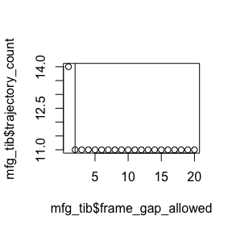

```
#> [[1]]
#> # A tibble: 20 × 3
#>    frame_gap_allowed trajectory_count file_id
#>                <dbl>            <dbl> <chr>
#>  1                 1               14 .
#>  2                 2               11 .
#>  3                 3               11 .
#>  4                 4               11 .
#>  5                 5               11 .
#>  6                 6               11 .
#>  7                 7               11 .
#>  8                 8               11 .
#>  9                 9               11 .
#> 10                10               11 .
#> 11                11               11 .
#> 12                12               11 .
#> 13                13               11 .
#> 14                14               11 .
#> 15                15               11 .
#> 16                16               11 .
#> 17                17               11 .
#> 18                18               11 .
#> 19                19               11 .
#> 20                20               11 .
#>
#> [[2]]
#> NULL
```

```r
motive_cleaned %>%
  visualize_frame_gap_choice(
    loops = 20
  )
```

The output of `visualize_frame_gap_choice()` is a tibble and plot of the number of trajectories after running `separate_trajectories()` with `max_frame_gap = 1`, `max_frame_gap = 2`, `max_frame_gap = 3`, etc. We can see that as the frame gap allowance increases, more bits of data are being linked into continuous trajectories and thus the total number of trajectories decreases. The vertical line on the plot indicates the “elbow” of the plot or the point at which counts of trajectories appear to stabilize and increases in the `max_frame_gap` allowance no longer effect the trajectory count very much.

### Autodetect

Setting `max_frame_gap = "autodetect"` rather than a numeric value uses the “elbow” of the plots from `visualize_frame_gap_choice()` to guesstimate the best value(s) for `max_frame_gap`.

**In addition to automatically selecting the `max_frame_gap` depending on the data, `autodetect` does so on a per subject basis rather than applying the same allowable frame gap to all data in the data set since frame gaps can vary between subjects.**

The cap on how high the `max_frame_gap` can go is defined as a proportion of the capture frame rate and set by the `frame_rate_proportion` argument, which defaults to `.10`.

```
#> autodetect is an experimental feature -- please report issues.
#> For subject: device02, estimated best value for max_frame_gap: 1
#> For subject: device03, estimated best value for max_frame_gap: 2
```

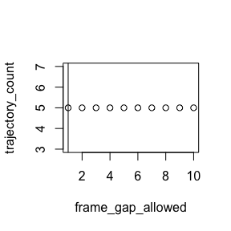

```
#> For subject: device05, estimated best value for max_frame_gap: 2
```

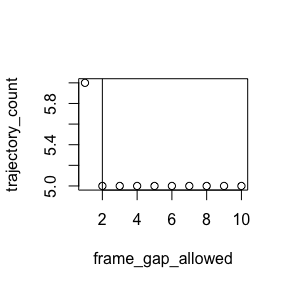

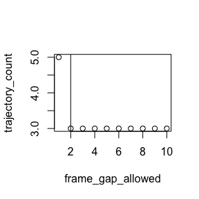

```r
motive_auto <-
  motive_cleaned %>%
  separate_trajectories(
    max_frame_gap = "autodetect",
    frame_rate_proportion = 0.1,
    frame_gap_messaging = TRUE,
    frame_gap_plotting = TRUE
  )
```

```r
## How many trajectories do we end up with?
length(unique(motive_auto$file_sub_traj))
```

```
#> [1] 13
```

Our sample data has 3 subjects so with `frame_gap_messaging = TRUE`, the `max_frame_gap` for each subject will be reported (the default is `FALSE`). `frame_gap_plotting = TRUE` will display the elbow plots for each subject, but also defaults to `FALSE`.